# Data Wrangling

### String splitting

Another very common data wrangling operation is string splitting. To illustrate how this comes up, we start with an illustrative example. Suppose we did not have the function `read_csv` available to use. We instead have to read a csv file using the base R function `readLines` like this:

```r
library(tidyverse)

filename <- system.file("extdata/murders.csv", package = "dslabs")
lines    <- readLines(filename)
```

This function reads in the data line-by-line to create a vector of strings. In this case one string for each row in the spreadsheet. The first six lines are:

```r
lines %>% head()
```

```
## [1] "state,abb,region,population,total" "Alabama,AL,South,4779736,135"
## [3] "Alaska,AK,West,710231,19"          "Arizona,AZ,West,6392017,232"
## [5] "Arkansas,AR,South,2915918,93"      "California,CA,West,37253956,1257"
```

We want to extract the values that are separated by a comma for each string in the vector. The command `str_split` does exactly this:

```r
x <- str_split(lines, ",")
x %>% head()
```

```
## [[1]]
## [1] "state"      "abb"        "region"     "population" "total"
##
## [[2]]
## [1] "Alabama" "AL"      "South"   "4779736" "135"
##
## [[3]]
## [1] "Alaska" "AK"     "West"   "710231" "19"
##
## [[4]]
## [1] "Arizona" "AZ"      "West"    "6392017" "232"
##
## [[5]]
## [1] "Arkansas" "AR"       "South"    "2915918"  "93"
##
## [[6]]
## [1] "California" "CA"         "West"       "37253956"   "1257"
```

Note that the first entry has the column names so we can separate that out:

```r
col_names <- x[[1]]
col_names
```

```
## [1] "state"      "abb"        "region"     "population" "total"
```

```r
x <- x[-1]
head(x)
```

```
## [[1]]
## [1] "Alabama" "AL"      "South"   "4779736" "135"
##
## [[2]]
## [1] "Alaska" "AK"     "West"   "710231" "19"
##
## [[3]]
## [1] "Arizona" "AZ"      "West"    "6392017" "232"
##
## [[4]]
## [1] "Arkansas" "AR"       "South"    "2915918"  "93"
##
## [[5]]
## [1] "California" "CA"         "West"       "37253956"   "1257"
##
## [[6]]
## [1] "Colorado" "CO"       "West"     "5029196"  "65"
```

To covert our list into a data frame we can use a shortcut provided by the `map` function in the purrr package. **The map function applies the same function to each element in a list**. So if we want to extract the first entry of each element in `x` we can write

```r
library(purrr)
map(x, function(y) y[1]) %>% head()
```

```
## [[1]]
## [1] "Alabama"
##
## [[2]]
## [1] "Alaska"
##
## [[3]]
## [1] "Arizona"
##
## [[4]]
## [1] "Arkansas"
##
## [[5]]
## [1] "California"
##
## [[6]]
## [1] "Colorado"
```

However, because this is such a common task, `purrr` provides a shortcut: if the second argument, instead of a function receives an integer, it assumes we want that entry:

```r
map(x, 1) %>% head()
```

```
## [[1]]
## [1] "Alabama"
##
## [[2]]
## [1] "Alaska"
##
## [[3]]
## [1] "Arizona"
##
## [[4]]
## [1] "Arkansas"
##
## [[5]]
## [1] "California"
##
## [[6]]
## [1] "Colorado"
```

For map to return a character vector instead of a list, we can use `map_chr`. Similarly, `map_int` returns integers. So to create our data frame we can use:

```r
dat <- data.frame(map_chr(x, 1),
                  map_chr(x, 2),
                  map_chr(x, 3),
                  map_chr(x, 4),
                  map_chr(x, 5),
                  stringsAsFactors = FALSE) %>%
  mutate_all(parse_guess) %>%
  setNames(col_names)
dat %>% head
```

```
##        state abb region population total
## 1    Alabama  AL  South    4779736   135
## 2     Alaska  AK   West     710231    19
## 3    Arizona  AZ   West    6392017   232
## 4   Arkansas  AR  South    2915918    93
## 5 California  CA   West   37253956  1257
## 6   Colorado  CO   West    5029196    65
```

```r
x <- str_split(lines, ",", simplify = TRUE)
col_names <- x[1,]
x <- x[-1,]
x <- x %>% as_tibble() %>%
  setNames(col_names) %>%
  mutate_all(parse_guess)
head(x)
```

```
## # A tibble: 6 × 5
##   state      abb   region population total
##   <chr>      <chr> <chr>       <dbl> <dbl>
## 1 Alabama    AL    South     4779736   135
## 2 Alaska     AK    West       710231    19
## 3 Arizona    AZ    West      6392017   232
## 4 Arkansas   AR    South     2915918    93
## 5 California CA    West     37253956  1257
## 6 Colorado   CO    West      5029196    65
```

### Case study 3: Extracing a table from a PDF

One of the datasets provided in dslabs shows scientific funding rates by gender in the Netherlands:

```r
library(dslabs)
data("research_funding_rates")
research_funding_rates
```

```
##            discipline applications_total applications_men applications_women
## 1   Chemical sciences                122               83                 39
## 2   Physical sciences                174              135                 39
## 3             Physics                 76               67                  9
## 4          Humanities                396              230                166
## 5  Technical sciences                251              189                 62
## 6   Interdisciplinary                183              105                 78
## 7 Earth/life sciences                282              156                126
## 8     Social sciences                834              425                409
## 9    Medical sciences                505              245                260
##   awards_total awards_men awards_women success_rates_total success_rates_men
## 1           32         22           10                26.2              26.5
## 2           35         26            9                20.1              19.3
## 3           20         18            2                26.3              26.9
## 4           65         33           32                16.4              14.3
## 5           43         30           13                17.1              15.9
## 6           29         12           17                15.8              11.4
## 7           56         38           18                19.9              24.4
## 8          112         65           47                13.4              15.3
## 9           75         46           29                14.9              18.8
##   success_rates_women
## 1                25.6
## 2                23.1
## 3                22.2
## 4                19.3
## 5                21.0
## 6                21.8
## 7                14.3
## 8                11.5
## 9                11.2
```

The data comes from a [paper](http://www.pnas.org/content/112/40/12349.abstract) published in the prestigious journal PNAS. However, the data is not provided in a spreadsheet, it is in a table in a PDF document:

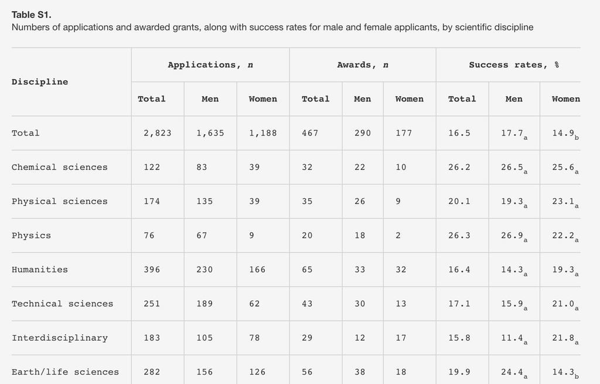

We could extract the numbers by hand, but this could lead to human error. Instead we can try to wrangle the data using R. We start by downloading the pdf document then importing into R. I have saved the paper as `pnas_article.pdf`.

```r
library("pdftools")
txt <- pdf_text("pnas_article.pdf")
```

```r
txt
```

```
## [1] "Supporting Information\nvan der Lee and Ellemers 10.1073/pnas.1510159112\nSI Text                                                                        applicants’ chances (i.e., evaluations and success rates) of\nGiven that the gender composition of the review committee might              …
## [2] "                       Table S1. Numbers of applications and awarded grants, along with success rates for male and\n                       female applicants, by scientific discipline\n                                                       Applications, n                    Awards, n         …
```

If we examine the object text we notice that it is a character vector with an entry for each page. So we keep the page we want:

```r
raw_data_research_funding_rates <- txt[2]
```

The steps above can actually be skipped because we include this raw data in the dslabs package as well

```r
data("raw_data_research_funding_rates")
```

Examining this object

```r
raw_data_research_funding_rates %>% head
```

```
## [1] "                        Table S1. Numbers of applications and awarded grants, along with success rates for male and\n                        female applicants, by scientific discipline\n                                                      Applications, n                    Awards, n        …
```

we see that it is a long string and each line on the page, including the table rows, are separated by the symbol for newline: `\n`. We can therefore create a list of the lines of the text as elements:

```r
tab <- str_split(raw_data_research_funding_rates, "\n")
tab
```

```
## [[1]]
##  [1] "                        Table S1. Numbers of applications and awarded grants, along with success rates for male and"
##  [2] "                        female applicants, by scientific discipline"
##  [3] "                                                      Applications, n                    Awards, n                      Success rates, %"
##  [4] "                        Discipline              Total     Men      Women         Total    Men       Women          Total    Men      Women"
##  [5] "                       Total                    2,823    1,635      1,188         467      290         177          16.5    17.7a      14.9b"
##  [6] "                        Chemical sciences         122       83          39         32       22           10         26.2    26.5a      25.6a"
##  [7] "                        Physical sciences         174      135          39         35       26            9         20.1    19.3a      23.1a"
##  [8] "                        Physics                    76       67           9         20       18            2         26.3    26.9a      22.2a"
##  [9] "                        Humanities                396      230         166         65       33           32         16.4    14.3a      19.3a"
## [10] "                        Technical sciences        251      189          62         43       30           13         17.1    15.9a      21.0a"
## [11] "                        Interdisciplinary         183      105          78         29       12           17         15.8    11.4a      21.8a"
## [12] "                        Earth/life sciences       282      156         126         56       38           18         19.9    24.4a      14.3b"
## [13] "                        Social sciences           834      425         409        112       65           47         13.4    15.3a      11.5a"
## [14] "                        Medical sciences          505      245         260         75       46           29         14.9    18.8a      11.2b"
## [15] "                           Success rates for male and female applicants with different subscripts differ reliably from one another (P < 0.05)."
## [16] "                        Table S2. Numbers of applications and awarded grants, along with success rates for male and"
## [17] "                        female applicants, by first-time applications vs. reapplications in one call, 2012"
## [18] "                                                         Applications, n                  Awards, n                     Success rates, %"
## [19] "                        Category                    Total    Men     Women         Total   Men       Women         Total     Men     Women"
## [20] "                       Total                         921     527        394         147      93          54         16.0    17.6i      13.7i"
## [21] "                        First-time applications      722     417        305         100      67          33         13.9i   16.1a      10.8b"
## [22] "                        Reapplications               199     110         89          47      26          21         23.6j   23.6ac     23.6c"
## [23] "                           Success rates for male and female applicants with different subscripts per row and column differ reliably from"
## [24] "                        one another (P < 0.05)."
## [25] "van der Lee and Ellemers www.pnas.org/cgi/content/short/1510159112                                                                             2 of 2"
## [26] ""
```

Because we start off with just one element in the string we end up with a list with just one entry.

```r
tab <- tab[[1]]
```

By examining this object

```r
tab %>% head
```

```
## [1] "                        Table S1. Numbers of applications and awarded grants, along with success rates for male and"
## [2] "                        female applicants, by scientific discipline"
## [3] "                                                      Applications, n                    Awards, n                      Success rates, %"
## [4] "                        Discipline              Total     Men      Women         Total    Men       Women          Total    Men      Women"
## [5] "                       Total                    2,823    1,635      1,188         467      290         177          16.5    17.7a      14.9b"
## [6] "                        Chemical sciences         122       83          39         32       22           10         26.2    26.5a      25.6a"
```

we see that the information for the column names is the third and forth entries:

```r
the_names_1 <- tab[3]
the_names_2 <- tab[4]
```

In the table the column information is spread across two lines. We want to create one vector with one name for each column. Using some of the functions we have just learned we do this:

Let’s start with the first line

```r
the_names_1
```

```
## [1] "                                                      Applications, n                    Awards, n                      Success rates, %"
```

We want to remove the leading space and the the stuff following the comma. We use regex for the latter. The we can obtain the elements by splitting using the space. We want to split only when there is 2 or more spaces to avoid splitting `success rate`. So we use the regex `\\s{2,}`

```r
the_names_1 <- the_names_1 %>%
  str_trim() %>%
  str_replace_all(",\\s.", "") %>%
  str_split("\\s{2,}", simplify = TRUE)
the_names_1
```

```
##      [,1]           [,2]     [,3]
## [1,] "Applications" "Awards" "Success rates"
```

Now looking at the second line:

```r
the_names_2
```

```
## [1] "                        Discipline              Total     Men      Women         Total    Men       Women          Total    Men      Women"
```

Here we want to trim the leading space and then split by space as we did for the first line:

```r
the_names_2 <- the_names_2 %>%
  str_trim() %>%
  str_split("\\s+", simplify = TRUE)
the_names_2
```

```
##      [,1]         [,2]    [,3]  [,4]    [,5]    [,6]  [,7]    [,8]    [,9]
## [1,] "Discipline" "Total" "Men" "Women" "Total" "Men" "Women" "Total" "Men"
##      [,10]
## [1,] "Women"
```

Now we can join these to generate one name for each column:

```r
tmp_names <- str_c(rep(the_names_1, each = 3), the_names_2[-1], sep = "_")
tmp_names
```

```
## [1] "Applications_Total"  "Applications_Men"    "Applications_Women"
## [4] "Awards_Total"        "Awards_Men"          "Awards_Women"
## [7] "Success rates_Total" "Success rates_Men"   "Success rates_Women"
```

```r
the_names <- c(the_names_2[1], tmp_names) %>%
  str_to_lower() %>%
  str_replace_all("\\s", "_")
the_names
```

```
##  [1] "discipline"          "applications_total"  "applications_men"
##  [4] "applications_women"  "awards_total"        "awards_men"
##  [7] "awards_women"        "success_rates_total" "success_rates_men"
## [10] "success_rates_women"
```

Now we are ready to get the actual data. By examining the `tab` object we notice that the information is in lines 6 through 14. We can use `str_split` again to achieve our goal:

```r
new_research_funding_rates <- tab[6:14] %>%
  str_trim %>%
  str_split("\\s{2,}", simplify = TRUE) %>%
  data.frame(stringsAsFactors = FALSE) %>%
  setNames(the_names) %>%
  mutate_at(-1, parse_number)
new_research_funding_rates %>% head()
```

```
##           discipline applications_total applications_men applications_women
## 1  Chemical sciences                122               83                 39
## 2  Physical sciences                174              135                 39
## 3            Physics                 76               67                  9
## 4         Humanities                396              230                166
## 5 Technical sciences                251              189                 62
## 6  Interdisciplinary                183              105                 78
##   awards_total awards_men awards_women success_rates_total success_rates_men
## 1           32         22           10                26.2              26.5
## 2           35         26            9                20.1              19.3
## 3           20         18            2                26.3              26.9
## 4           65         33           32                16.4              14.3
## 5           43         30           13                17.1              15.9
## 6           29         12           17                15.8              11.4
##   success_rates_women
## 1                25.6
## 2                23.1
## 3                22.2
## 4                19.3
## 5                21.0
## 6                21.8
```

We can see that the objects are identical:

```r
identical(research_funding_rates, new_research_funding_rates)
```

```
## [1] TRUE
```

### Recoding

Another common operation involving strings is recoding the names of categorical variables. For example, if you have really long names for your levels and you will be displaying them in plots, you might want to use shorter versions of these names. For example, in a character vector with country names you might want to change “United States of America” to “USA” and “United Kingdom” to UK, and so on. We can do this with `case_when` but the tidyverse offers options that are specifically designed for this task: the `recode` function.

Here is an example showing how to rename countries with long names:

```r
library(dslabs)
data("gapminder")
```

Suppose we want to show life expectancy time series by country for the Caribbean:

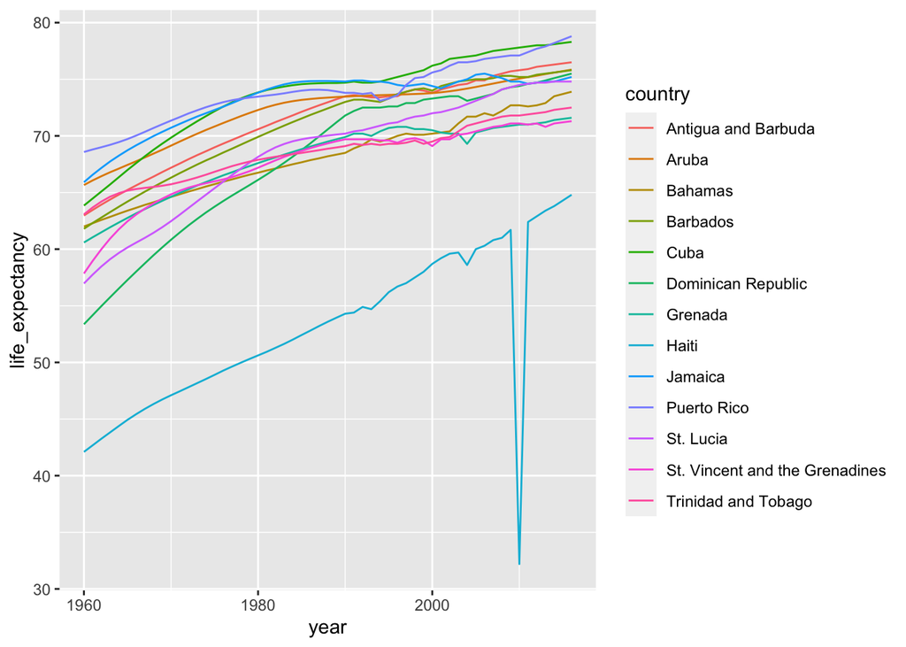

```r
gapminder %>%
  filter(region=="Caribbean") %>%
  ggplot(aes(year, life_expectancy, color = country)) +
  geom_line()
```

The plot is what we want but much of the space is wasted to accomodate some of the long country names.

```r
gapminder %>%
  filter(region=="Caribbean") %>%
  filter(str_length(country) >= 12) %>%
  distinct(country)
```

```
##                          country
## 1            Antigua and Barbuda
## 2             Dominican Republic
## 3 St. Vincent and the Grenadines
## 4            Trinidad and Tobago
```

We have four countries with names longer than 12 characters. These names appear once for each year in the gapminder dataset and once we pick nicknames we need to change them all consistently. The `recode` function can be used to do this:

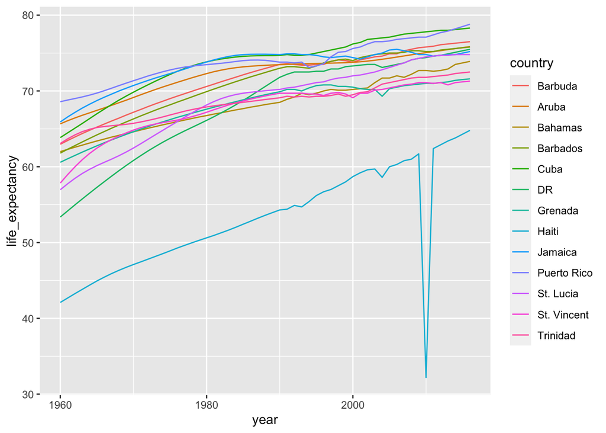

```r
gapminder %>% filter(region == "Caribbean") %>%
  mutate(country = recode(country,
                          `Antigua and Barbuda`="Barbuda",
                          `Dominican Republic` = "DR",
                          `St. Vincent and the Grenadines` = "St. Vincent",
                          `Trinidad and Tobago` = "Trinidad")) %>%
  ggplot(aes(year, life_expectancy, color = country)) +
  geom_line()
```

Other similar functions include `recode_factor` and `fct_recoder` in the forcats tidyverse package.